# 02_Datawrangling

Chiara Draxler

6 1 2022

#1.Load Data

```r
load("Fake_cccu_complete.RData")
```

#2.Load Packages

```r
#loading dplyr
library("dplyr")
library(formr)
library("tidyverse")
```

#3. Selecting necessary columnsfor thesis’ question

```r
#Getting overview over columns
colnames(Fake_cccu_complete)
```

```
##   [1] "CASEID"                   "WEIGHT"
##   [3] "TM_START"                 "TM_FINISH"
##   [5] "DURATION"                 "INTVLANG"
##   [7] "MAINLANG"                 "DOV_Q26_1"
##   [9] "DOV_Q26_2"                "DOV_Q26_3"
##  [11] "DOV_Q26_4"                "DOV_Q26_5"
##  [13] "DOV_Q26_6"                "DOV_Q26_REFUSED"
##  [15] "EVERSEX"                  "TUBAL"
##  [17] "PSNIP"                    "NOWPREG"
##  [19] "MARRIED"                  "COHAB"
##  [21] "SEPARATE"                 "NEVMAR"
##  [23] "WIDOW"                    "DIVORCE"
##  [25] "XMAR"                     "STILLP"
##  [27] "DATING"                   "NDATING"
##  [29] "Q3B_A"                    "Q3B_B"
```

[output cut: 308 more lines]

List of necessary columns: CASEID WAVE WEIGHT AGE DEGREE POVRATE POVCAT TYPEINS MEDPROB GAPINS HLTHPROB AVOID FEELPG NBIRTHS BIRTH3MO PREG MONTHSA MONTHSB MONTHSC MOTNHSD1 MONTHSD3 MONTHSE1 MONTHSE3 YEARSA YEARSB YEARSC YEARSD1 YEARSD2 YEARSE1 YEARSE2 SEXSAT SEXMO NSEXMO RASAT1 RASAT2 RASAT3 RASAT4 RASAT5 RSATIS SATISBC PILL PATCH RING DEPO IUD IMPLANT YPILL YPATCH YRING YDEPO YIMPLANT YIUD MPILL MPATCH MRING MDEPO MIMPLANT MIUD Q23A_PILL Q23A_PATCH Q23A_RING Q23A_DEPO Q23A_IMPLANT Q23A_IUD TIMEUSE FREQBAR FREQBARB WITHDRAW VASECTOMY CONDOM NFP SPERM NOBARRIER XBARR DOV_Q26_1 DOV_Q26_2 DOV_Q26_3 DOV_Q26_4 DOV_Q26_5 DOV_Q26_6 DOV_Q26_REFUSED Time

```r
#Select variables

Fake_cccu_complete1 <- Fake_cccu_complete %>%
  select(CASEID, WAVE,EC,AGE, DEGREE,
        POVRATE, TYPEINS,MEDPROB,
        GAPINS, HLTHPROB, AVOID,AVOID3, FEELPG,
        NBIRTHS, BIRTH3MO, PREG,CURRENT,
        Q3B_A, Q3B_B, Q3B_C, Q3B_D1,
        Q4_C, Q4_D1,
        MONTHSA, MONTHSB, MONTHSC, MONTHSD1,
        YEARSA, YEARSB, YEARSC, YEARSD1,
        SEXSAT,
        SEXMO, NSEXMO, starts_with("RSAT"),#includes RSATIS as overall measure for satisfaciton with barrier methods
        SATISBC, starts_with("Q23D"),HORMONAL,
        PILL,PATCH,RING,DEPO,IUD,
        IMPLANT, YPILL, YPATCH, YRING,
        YDEPO, YIMPLANT, YIUD, MPILL, MPATCH,
        MRING, MDEPO, MIMPLANT, MIUD,
        starts_with("Q23A_"), TIMEUSE, WITHDRAWR,VASECTOMY,CONDOMR,
        NFPR,SPERMR,NOBARRIER,XBARR, starts_with("DOV_Q26_"), SP1VAS, SP2VAS)

#double check column WAVE
table(Fake_cccu_complete1$WAVE)
```

```
##
##   t1   t2   t3   t4
## 4634 3207 2398 1842
```

#4. Variable Wrangling

##EC (for exclusion)

```r
table(Fake_cccu_complete1$EC)
```

```
##
##   (-1) Refused         (0) No        (1) Yes  (3) Dont Know (4) Didnt care
##             35           5547             98              0              0
```

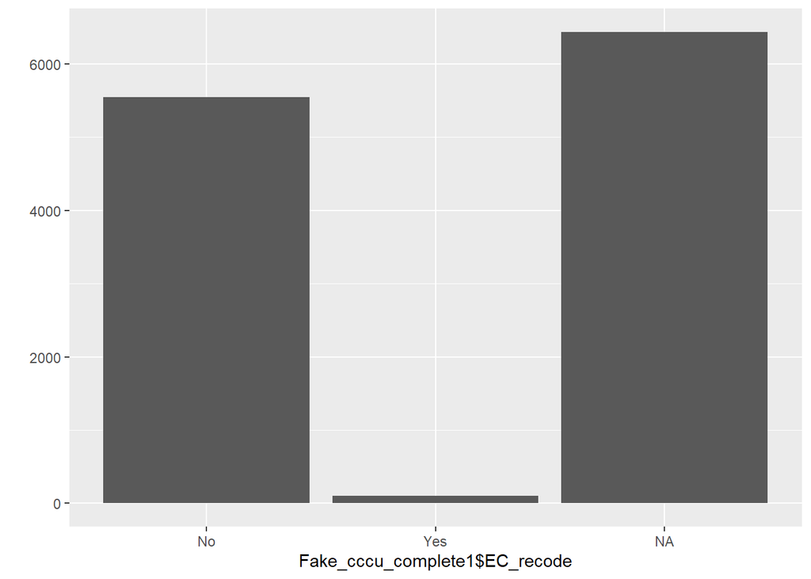

```r
Fake_cccu_complete1 <- Fake_cccu_complete1 %>%
  mutate(EC_recode = ifelse(EC == "(0) No", 0,
                            ifelse(EC == "(1) Yes", 1,NA)))



#factorize
Fake_cccu_complete1$EC_recode<-factor(Fake_cccu_complete1$EC_recode, levels = c(0,1), labels = c("No", "Yes"))

qplot(Fake_cccu_complete1$EC_recode)
```

##4.0 Wave

```r
Fake_cccu_complete1$WAVE <- as.factor(Fake_cccu_complete1$WAVE)

class(Fake_cccu_complete1$WAVE)
```

```
## [1] "factor"
```

##4.1 Degree

```r
#Overview over Column
table(Fake_cccu_complete1$DEGREE)
```

```
##
##                                                          (-2) Not asked
##                                                                       0
##                                                            (-1) refused
##                                                                       0
##                                                (01) No formal education
##                                                                       9
##                                        (02) 1st, 2nd, 3rd, or 4th grade
##                                                                       7
##                                                   (03) 5th or 6th grade
##                                                                      66
##                                                   (04) 7th or 8th grade
##                                                                      61
##                                                          (05) 9th grade
##                                                                      78
##                                                         (06) 10th grade
##                                                                     115
##                                                         (07) 11th grade
##                                                                     107
##                                              (08) 12th grade NO DIPLOMA
##                                                                     144
## (09) HIGH SCHOOL GRADUATE - high school DIPLOMA or the equivalent (GED)
##                                                                    1652
##                                            (10) Some college, no degree
##                                                                    3116
##                                                   (11) Associate degree
##                                                                    1325
##                                                   (12) Bachelors degree
##                                                                    3721
##                                                     (13) Masters degree
##                                                                    1377
##                                   (14) Professional or Doctorate degree
##                                                                     303
```

Values are: (-2) Not asked (-1) refused (01) No formal education (02) 1st, 2nd, 3rd, or 4th grade (03) 5th or 6th grade (04) 7th or 8th grade (05) 9th grade (06) 10th grade (07) 11th grade (08) 12th grade NO DIPLOMA (09) HIGH SCHOOL GRADUATE - high school DIPLOMA or the equivalent (GED) (10) Some college, no degree (11) Associate degree (12) Bachelors degree (13) Masters degree (14) Professional or Doctorate degree

we want to keep all numbers (not necessary to summarize in one category) and there is no category twice (with different number), we can simply recode it

```r
Fake_cccu_complete1<- Fake_cccu_complete1 %>%
  mutate(DEGREE_recode = recode(DEGREE,
                                "(-2) Not asked"="NA",
                                "(-1) refused"="NA",
                                "(01) No formal education" ="1",
                                "(02) 1st, 2nd, 3rd, or 4th grade" = "2",
                                "(03) 5th or 6th grade" = "3",
                                "(04) 7th or 8th grade" = "4",
                                "(05) 9th grade" = "5",
                                "(06) 10th grade" = "6",
                                "(07) 11th grade" = "7",
                                "(08) 12th grade NO DIPLOMA" = "8",
                                "(09) HIGH SCHOOL GRADUATE - high school DIPLOMA or the equivalent (GED)" = "9",
                                "(10) Some college, no degree" = "10",
                                "(11) Associate degree" = "11",
                                "(12) Bachelors degree" = "12",
                                "(13) Masters degree" = "13",
                                "(14) Professional or Doctorate degree" = "14"
))
table(Fake_cccu_complete1$DEGREE)
```

```
##
##                                                          (-2) Not asked
##                                                                       0
##                                                            (-1) refused
##                                                                       0
##                                                (01) No formal education
##                                                                       9
##                                        (02) 1st, 2nd, 3rd, or 4th grade
##                                                                       7
##                                                   (03) 5th or 6th grade
##                                                                      66
##                                                   (04) 7th or 8th grade
##                                                                      61
##                                                          (05) 9th grade
##                                                                      78
##                                                         (06) 10th grade
##                                                                     115
##                                                         (07) 11th grade
##                                                                     107
##                                              (08) 12th grade NO DIPLOMA
##                                                                     144
## (09) HIGH SCHOOL GRADUATE - high school DIPLOMA or the equivalent (GED)
##                                                                    1652
##                                            (10) Some college, no degree
##                                                                    3116
##                                                   (11) Associate degree
##                                                                    1325
##                                                   (12) Bachelors degree
##                                                                    3721
##                                                     (13) Masters degree
##                                                                    1377
##                                   (14) Professional or Doctorate degree
##                                                                     303
```

```r
table(Fake_cccu_complete1$DEGREE_recode)
```

```
##
##   NA    1    2    3    4    5    6    7    8    9   10   11   12   13   14
##    0    9    7   66   61   78  115  107  144 1652 3116 1325 3721 1377  303
```

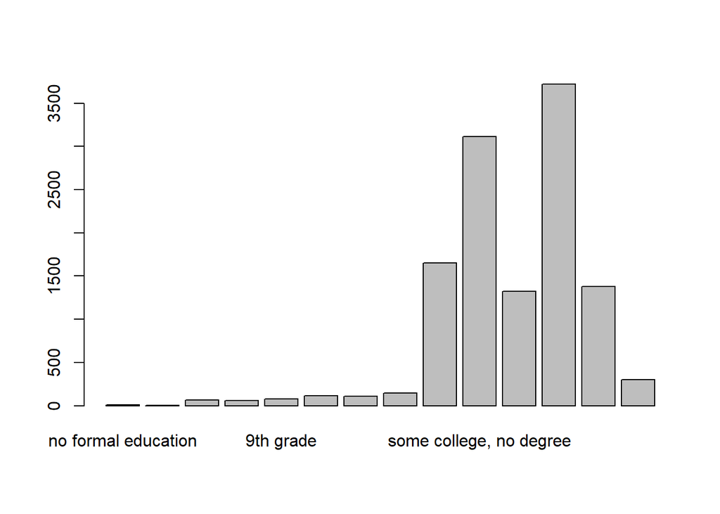

```r
#Factorizing it with levels
Fake_cccu_complete1$DEGREE_recode<-
factor(Fake_cccu_complete1$DEGREE_recode, levels = c(1,2,3,4,5,6,7,8,9,10,11,12,13,14), labels = c("no formal education", "1st to 4th grade", "5th/6th grade", "7th/8th grade", "9th grade", "10th grade", "11th grade", "12th grade / no diploma", "high school diploma or equivalent", "some college, no degree", "associate degree", "bachelors degree", "masters degree", "professional or doctoral degree"))


plot(Fake_cccu_complete1$DEGREE_recode)
```

## 4.2 Age

```r
#overview

table(Fake_cccu_complete1$AGE)
```

```
##
##  18  19  20  21  22  23  24  25  26  27  28  29  30  31  32  33  34  35  36  37
##  75 196 282 456 557 704 916 978 727 804 934 842 613 477 430 506 488 496 453 358
##  38  39
## 425 364
```

```r
#as.numeric
Fake_cccu_complete1$AGE <- as.numeric(Fake_cccu_complete1$AGE)

class(Fake_cccu_complete1$AGE)
```

```
## [1] "numeric"
```

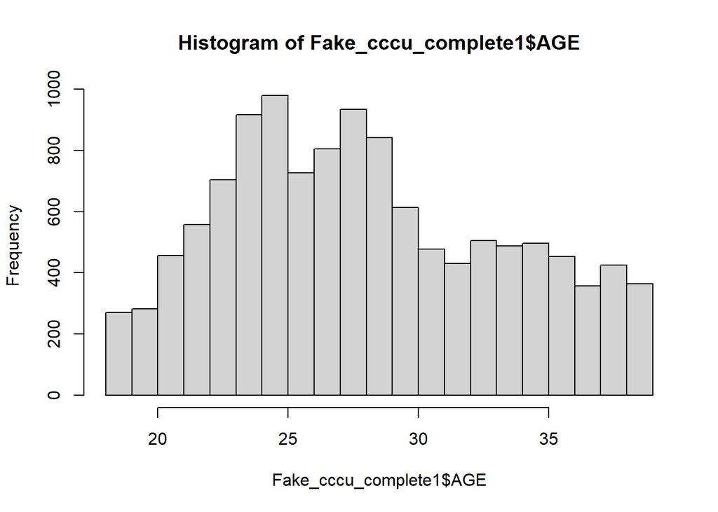

```r
hist(Fake_cccu_complete1$AGE)
```

##4.3 POVERTY: POVRATE

```r
table(Fake_cccu_complete1$POVRATE)
```

```
##
##   13   14   16   18   19   20   21   22   23   25   26   27   28   29   30   32
##    4    5   25   19   19   11   37   49   18    1  131   49    7    5    1   96
##   33   35   36   37   38   39   40   41   42   44   45   46   48   49   50   51
##   96    2   17   31   41   10   32   44   15   54   59   33   22   27   17   15
##   53   54   55   56   57   58   59   60   63   64   65   69   70   71   72   73
##    1   31   18   58   12  138   37   33   21    8   18   11   38   24   42   58
##   74   76   77   78   79   82   83   84   86   87   89   90   91   92   93   94
##   83   73    2   15    4   69   36    1    1   27   45   55   21   45    7    1
##   95   96   98  100  101  102  103  105  106  107  108  113  115  116  117  118
##    3   66   56   33   10   23   31   24    1    2    2   68   63   46   63  143
##  119  120  121  123  126  129  130  136  138  139  141  142  144  145  146  149
##   67   64   10   29    3    5    1   49   77   38  145   23   74  113    1   88
##  152  154  157  158  159  163  166  167  170  174  177  178  182  183  187  189
##   21    1   41    3   70  101   59   52   53   22  122   10   91    3    2    2
```

[output cut: 18 more lines]

```r
Fake_cccu_complete1$POVRATE <- as.numeric(Fake_cccu_complete1$POVRATE)

class(Fake_cccu_complete1$POVRATE)
```

```
## [1] "numeric"
```

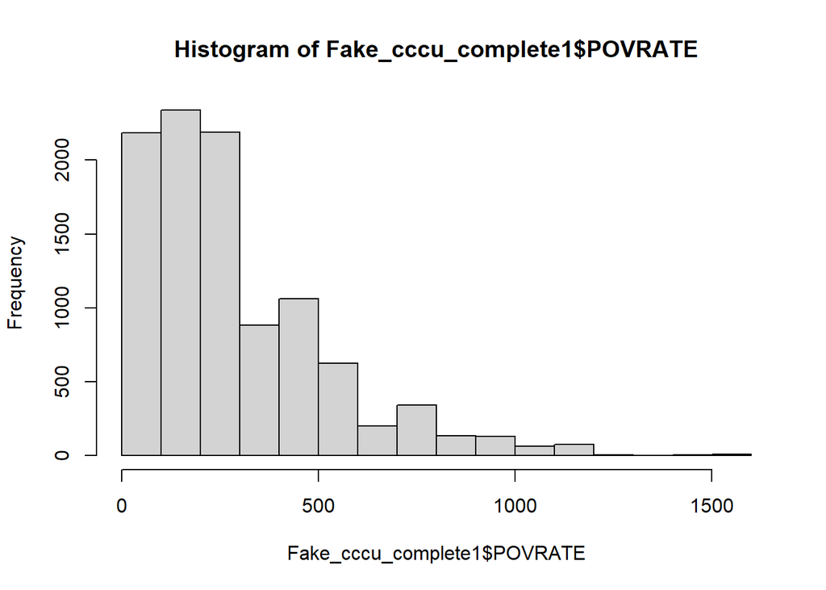

```r
hist(Fake_cccu_complete1$POVRATE)
```

##4.4 TYPE of INSURANCE

```r
#Overview
table(Fake_cccu_complete1$TYPEINS)
```

```
##
##                                                                                                                 (-1) Refused
##                                                                                                                            0
##                       (1) Private health insurance I get through my job or school, a family member or that I pay for myself.
##                                                                                                                         6817
##                              (2) (Medicaid Program - BASED ON PPSTATEN) or some other government-sponsored health insurance.
##                                                                                                                          741
##                                                                                      (3) Some other type of health insurance
##                                                                                                                           82
##                                                                                           (4) I don't have health insurance.
##                                                                                                                         1961
##                                                       (2) {#\\.POV_Q38} or some other government-sponsored health insurance.
##                                                                                                                          761
## (0) Insurance obtained through a health insurance marketplace or exchange, such as www.healthcare.gov or {state-specific mar
##                                                                                                                          133
##                  (1) Private health insurance that I get through my job or school, a family member or that I pay for myself.
##                                                                                                                         1221
##                                                           (2) {PPSTATE} or some other government-sponsored health insurance.
##                                                                                                                          239
##        (5) Insurance obtained through a health insurance marketplace or exchange, such as www.healthcare.gov{#POV_PROGNAME_Q
##                                                                                                                            0
```

```r
Fake_cccu_complete1<- Fake_cccu_complete1 %>%
  mutate(TYPEINS_recode = recode(TYPEINS,
                                "(-1) Refused"= "NA",
                                "(1) Private health insurance I get through my job or school, a family member or that I pay for myself." ="1",
                                "(2) (Medicaid Program - BASED ON PPSTATEN) or some other government-sponsored health insurance." = "1",
                                "(3) Some other type of health insurance" = "1",
                                "(4) I don't have health insurance." = "0",
                                "(2) {#\\.POV_Q38} or some other government-sponsored health insurance." = "1",
                                "(0) Insurance obtained through a health insurance marketplace or exchange, such as www.healthcare.gov or {state-specific mar" = "1",
                                "(1) Private health insurance that I get through my job or school, a family member or that I pay for myself." = "1",
                                "(2) {PPSTATE} or some other government-sponsored health insurance." = "1",
                                "(5) Insurance obtained through a health insurance marketplace or exchange, such as www.healthcare.gov{#POV_PROGNAME_Q" = "1"))

table(Fake_cccu_complete1$TYPEINS_recode)
```

```
##
##   NA    1    0
##    0 9994 1961
```

```r
sum(is.na(Fake_cccu_complete1$TYPEINS))
```

```
## [1] 126
```

```r
#Factorize
Fake_cccu_complete1$TYPEINS_recode<- factor(Fake_cccu_complete1$TYPEINS_recode, levels = c(0,1), labels = c("No", "Yes"))
table(Fake_cccu_complete1$TYPEINS_recode)
```

```
##
##   No  Yes
## 1961 9994
```

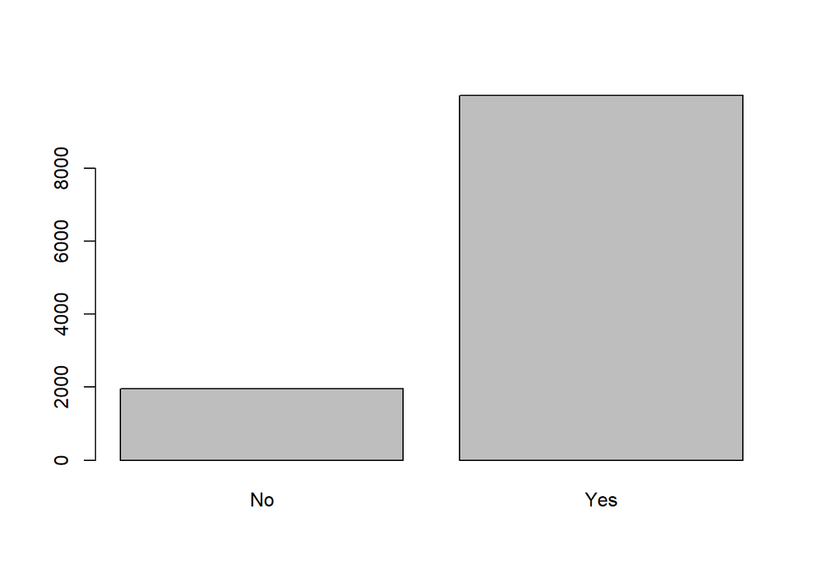

```r
plot(Fake_cccu_complete1$TYPEINS_recode)
```

##4.5 MEDICAL PROBLEMS

```r
table(Fake_cccu_complete1$MEDPROB)
```

```
##
##  (0) No (1) Yes
##   10933    1148
```

```r
Fake_cccu_complete1<- Fake_cccu_complete1 %>%
  mutate(MEDPROB_recode = recode(MEDPROB,
                                 "(0) No"="0",
                                 "(1) Yes" ="1"))



#factorize
Fake_cccu_complete1$MEDPROB_recode<- factor(Fake_cccu_complete1$MEDPROB_recode, levels = c(0,1), labels = c("No", "Yes"))
table(Fake_cccu_complete1$MEDPROB_recode)
```

```
##
##    No   Yes
## 10933  1148
```

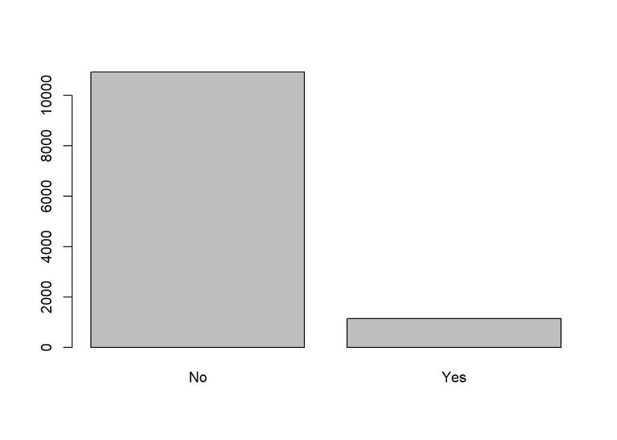

```r
plot(Fake_cccu_complete1$MEDPROB_recode)
```

##4.6 GAPS in INSURANCE

```r
#overview
table(Fake_cccu_complete1$GAPINS)
```

```
##
##  (0) no (1) yes
##    9303    2666
```

```r
#recode
Fake_cccu_complete1<- Fake_cccu_complete1 %>%
  mutate(GAPINS_recode = recode(GAPINS,
                                 "(0) no"="0",
                                "(1) yes"="1"))
#control
table(Fake_cccu_complete1$GAPINS_recode)
```

```
##
##    0    1
## 9303 2666
```

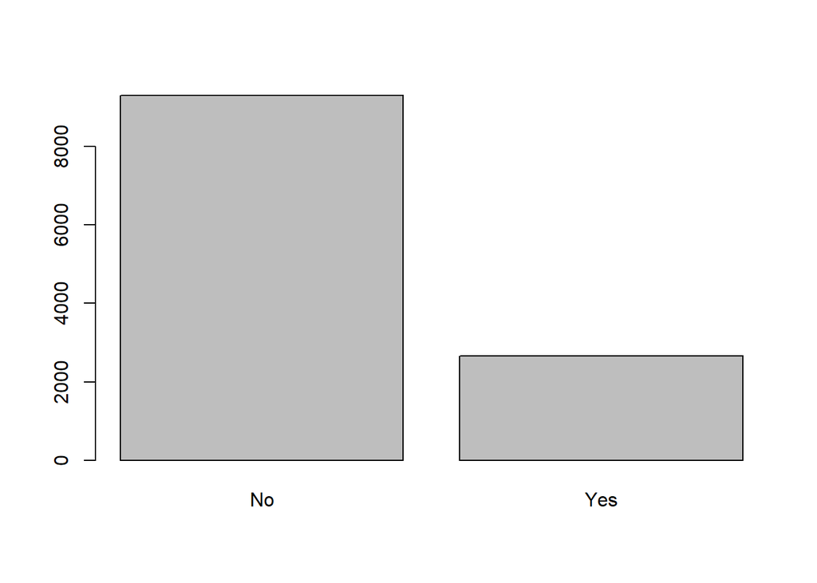

```r
#factorize
Fake_cccu_complete1$GAPINS_recode<-factor(Fake_cccu_complete1$GAPINS_recode, levels = c(0,1), labels = c("No", "Yes"))

plot(Fake_cccu_complete1$GAPINS_recode)
```

##4.7 HEALTH PROBLEMS

```r
#overview
table(Fake_cccu_complete1$HLTHPROB)
```

```
##
##   (-1) Refused         (0) No        (1) Yes  (3) Dont Know (4) Didnt care
##              0           3579            813            216              0
```

Recoding values

```r
#Recoding
Fake_cccu_complete1<- Fake_cccu_complete1 %>%
  mutate(HLTHPROB_recode = recode(HLTHPROB,
                                    "(-1) Refused"="NA",
                                  "(0) No"="0",
                                  "(1) Yes"="1",
                                  "(3) Dont Know"="NA",
                                  "(4) Didnt care"="NA"))
table(Fake_cccu_complete1$HLTHPROB_recode)
```

```
##
##   NA    0    1
##  216 3579  813
```

```r
#factorize
Fake_cccu_complete1$HLTHPROB_recode<-factor(Fake_cccu_complete1$HLTHPROB_recode, levels = c(0,1), labels = c("No", "Yes"))

sum(is.na(Fake_cccu_complete1$HLTHPROB_recode))
```

```
## [1] 7689
```

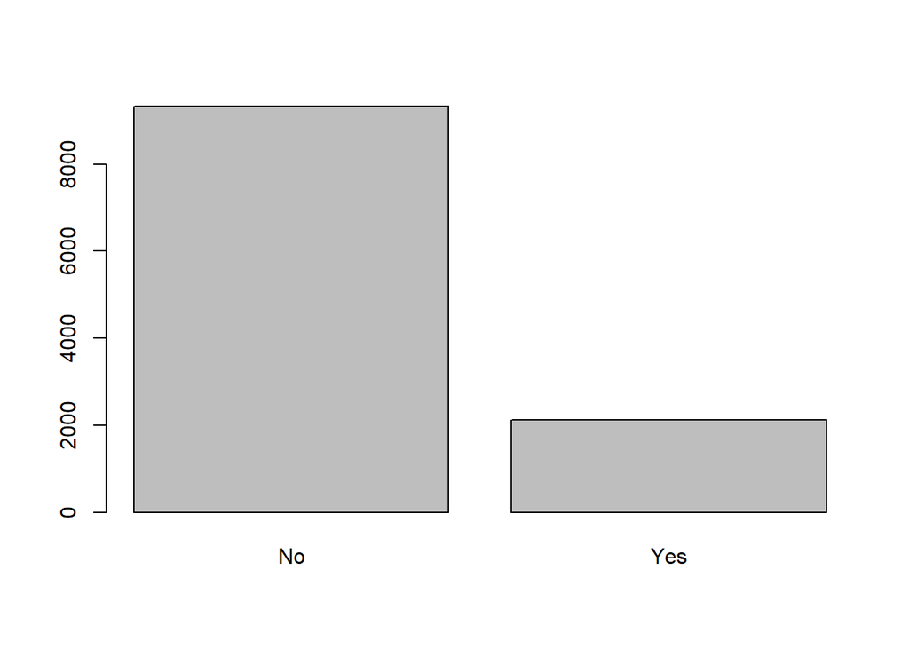

```r
#fill for each wave after t1 (for t2,t3,t4)
Fake_cccu_complete1 = Fake_cccu_complete1 %>%
group_by(CASEID) %>%
fill(HLTHPROB_recode)

plot(Fake_cccu_complete1$HLTHPROB_recode)
```

##4.8 Avoid Pregnancy

```r
#overview
table(Fake_cccu_complete1$AVOID)
```

```
##
##                                  (-1) Refused
##                                             0
## (1) Not at all important to avoid pregnancy 1
##                                          1258
##                                         (2) 2
##                                           404
##                                         (3) 3
##                                           736
##                                         (4) 4
##                                          1038
##                                         (5) 5
##                                          1335
##       (6) Very important to avoid pregnancy 6
##                                          4559
```

```r
table(Fake_cccu_complete1$AVOID3)
```

```
##
##                                  (-1) Refused
##                                             0
## (1) Not at all important to avoid pregnancy 1
##                                           324
##                                         (2) 2
##                                            98
##                                         (3) 3
##                                           174
##                                         (4) 4
##                                           251
##                                         (5) 5
##                                           338
##       (6) Very important to avoid pregnancy 6
##                                          1069
```

```r
table(is.na(Fake_cccu_complete1$AVOID))
```

```
##
## FALSE  TRUE
##  9330  2751
```

```r
crosstabs(~is.na(AVOID) + WAVE, data = Fake_cccu_complete1)
```

```
##             WAVE
## is.na(AVOID)   t1   t2   t3   t4
##        FALSE 4606 3006    0 1718
##        TRUE    28  201 2398  124
```

```r
crosstabs(~is.na(AVOID3) + WAVE, data = Fake_cccu_complete1)
```

```
##              WAVE
## is.na(AVOID3)   t1   t2   t3   t4
##         FALSE    0    0 2254    0
##         TRUE  4634 3207  144 1842
```

```r
#AVOID is always missing in t3, therefore  just replace missing values in AVOID with non-missing values in AVOID3
#everything else is the same (scale, etc.)

Fake_cccu_complete1 <- Fake_cccu_complete1 %>%
  mutate(AVOID_r = ifelse(is.na(AVOID), as.character(AVOID3), as.character(AVOID)))

crosstabs(~is.na(AVOID_r) + WAVE, data = Fake_cccu_complete1)
```

```
##               WAVE
## is.na(AVOID_r)   t1   t2   t3   t4
##          FALSE 4606 3006 2254 1718
##          TRUE    28  201  144  124
```

```r
table(Fake_cccu_complete1$AVOID_r)
```

```
##
## (1) Not at all important to avoid pregnancy 1
##                                          1582
##                                         (2) 2
##                                           502
##                                         (3) 3
##                                           910
##                                         (4) 4
##                                          1289
##                                         (5) 5
##                                          1673
##       (6) Very important to avoid pregnancy 6
##                                          5628
```

```r
#recode

Fake_cccu_complete1 <- Fake_cccu_complete1 %>%
  mutate(Avoid_r = ifelse(AVOID_r == "(1) Not at all important to avoid pregnancy 1", 1,
                          ifelse(AVOID_r == "(2) 2", 2,
                                 ifelse(AVOID_r == "(3) 3", 3,
                                        ifelse(AVOID_r == "(4) 4" , 4,
                                               ifelse(AVOID_r == "(5) 5" , 5,
                                                      ifelse(AVOID_r == "(6) Very important to avoid pregnancy 6",6 , NA)))))))


table(Fake_cccu_complete1$Avoid_r)
```

```
##
##    1    2    3    4    5    6
## 1582  502  910 1289 1673 5628
```

```r
sum(is.na(Fake_cccu_complete1$AVOID))
```

```
## [1] 2751
```

```r
sum(is.na(Fake_cccu_complete1$Avoid_r))
```

```
## [1] 497
```

```r
Fake_cccu_complete1$Avoid_r <- as.numeric(Fake_cccu_complete1$Avoid_r)
class(Fake_cccu_complete1$Avoid_r)
```

```
## [1] "numeric"
```

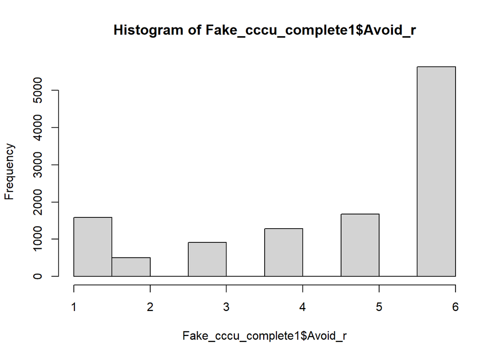

```r
hist(Fake_cccu_complete1$Avoid_r)
```

##4.9 FEEL About Pregnancy

```r
#overview
table(Fake_cccu_complete1$FEELPG)
```

```
##
##                          (-1) Refused (1) Not at all happy to be pregnant 1
##                                     0                                  2569
##                                 (2) 2                                 (3) 3
##                                  1422                                  1821
##                                 (4) 4                                 (5) 5
##                                  2167                                  1468
##       (6) Very happy to be pregnant 6
##                                  2110
```

```r
#recode

Fake_cccu_complete1 <- Fake_cccu_complete1 %>%
  mutate(FEELPG_recode = ifelse(FEELPG == "(1) Not at all happy to be pregnant 1", 1, ifelse(FEELPG == "(2) 2", 2,
                                                                                                   ifelse(FEELPG == "(3) 3", 3,
                                                                                                          ifelse(FEELPG == "(4) 4", 4,
                                                                                                                 ifelse(FEELPG == "(5) 5", 5, ifelse(FEELPG == "(6) Very happy to be pregnant 6",6, NA)))))))


table(Fake_cccu_complete1$FEELPG_recode)
```

```
##
##    1    2    3    4    5    6
## 2569 1422 1821 2167 1468 2110
```

```r
sum(is.na(Fake_cccu_complete1$FEELPG_recode))
```

```
## [1] 524
```

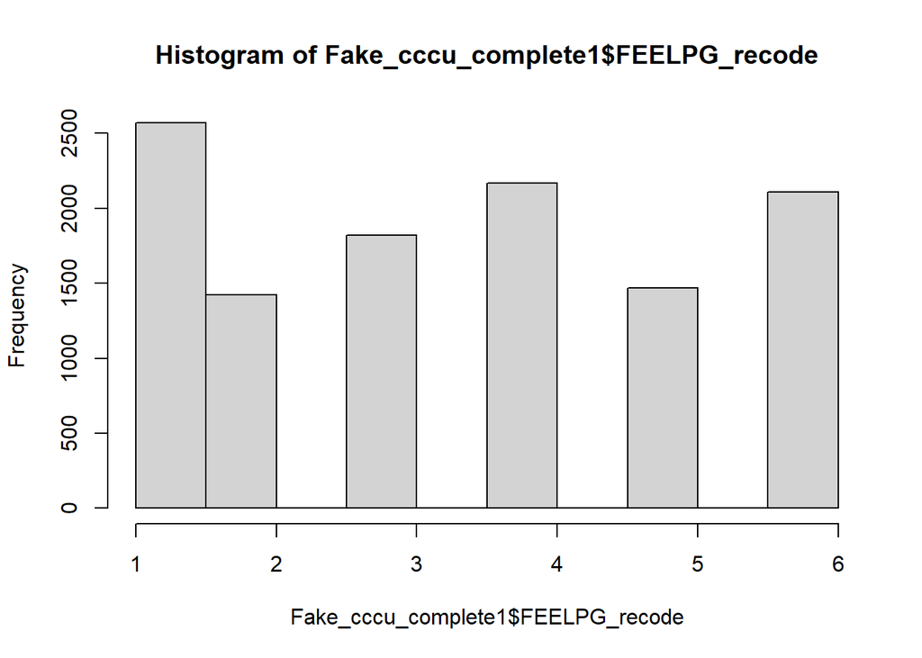

```r
Fake_cccu_complete1$FEELPG_recode <- as.numeric(Fake_cccu_complete1$FEELPG_recode)


hist(Fake_cccu_complete1$FEELPG_recode)
```

##4.10 NUMBER of Kids at t1

```r
table(Fake_cccu_complete1$NBIRTHS)
```

```
##
##         (0) 0         (1) 1         (2) 2         (3) 3 (4) 4 or more
##          2257           989           861           352           167
```

```r
Fake_cccu_complete1<- Fake_cccu_complete1 %>%
  mutate(NKIDS_t1 = recode(NBIRTHS,
                                    "(0) 0"="0",
                                  "(1) 1"="1",
                                 "(2) 2" = "2",
                                 "(3) 3" = "3",
                                 "(4) 4 or more" = "4"))
table(Fake_cccu_complete1$NKIDS_t1)
```

```
##
##    0    1    2    3    4
## 2257  989  861  352  167
```

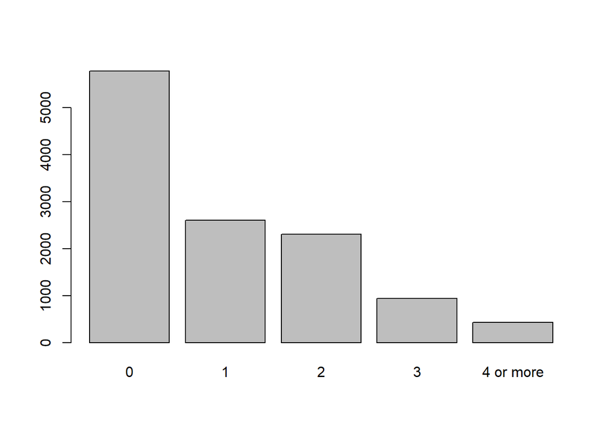

```r
#factorize
Fake_cccu_complete1$NKIDS_t1<-factor(Fake_cccu_complete1$NKIDS_t1, levels = c(0,1,2,3,4), labels = c("0", "1", "2", "3", "4 or more"))


#fill for each wave after t1 (for t2,t3,t4)
Fake_cccu_complete1 = Fake_cccu_complete1 %>%
group_by(CASEID) %>%
fill(NKIDS_t1)


plot(Fake_cccu_complete1$NKIDS_t1)
```

##4.11 Pregnant between two waves? Since September 2012, did you experience any of the following?

```r
#overview
table(Fake_cccu_complete1$PREG)
```

```
##
##            (-1) Refused (1) I had a miscarriage   (2) I had an abortion
##                       0                     106                      34
##        (3) I had a baby                   (4) I (5) I might be pregnant
##                     262                     422                     208
##   (6) None of the above
##                    6388
```

```r
table(Fake_cccu_complete1$CURRENT)
```

```
##
##                               (-1) Refused
##                                          0
## (1) I had a baby within the last 3 months.
##                                        144
##               (2) I am currently pregnant.
##                                          0
##         (3) I might currently be pregnant.
##                                        169
##                     (4) None of the above.
##                                       4310
```

```r
table(is.na(Fake_cccu_complete1$PREG))
```

```
##
## FALSE  TRUE
##  7420  4661
```

```r
crosstabs(~is.na(PREG) + WAVE, data = Fake_cccu_complete1)
```

```
##            WAVE
## is.na(PREG)   t1   t2   t3   t4
##       FALSE    0 3198 2389 1833
##       TRUE  4634    9    9    9
```

```r
crosstabs(~is.na(CURRENT) + WAVE, data = Fake_cccu_complete1)
```

```
##               WAVE
## is.na(CURRENT)   t1   t2   t3   t4
##          FALSE 4623    0    0    0
##          TRUE    11 3207 2398 1842
```

```r
#PREG is always missing in t1, therefore   replace missing values in PREG with non-missing values in CURRENT
#scale of CURRENT needs to be the same as in PREG

#translate values from CURRENT in scale PREG

Fake_cccu_complete1 <- Fake_cccu_complete1 %>%
  mutate(CURRENT_r = ifelse(CURRENT == "(1) I had a baby within the last 3 months.", "(3) I had a baby",
                            ifelse(CURRENT == "(2) I am currently pregnant.", "(4) I",
                                   ifelse(CURRENT == "(3) I might currently be pregnant.", "(5) I might be pregnant",
                                          ifelse(CURRENT == "(4) None of the above.", "(6) None of the above", CURRENT)))))

table(Fake_cccu_complete1$CURRENT_r)
```

```
##
##        (3) I had a baby (5) I might be pregnant   (6) None of the above
##                     144                     169                    4310
```

```r
#combine values now

Fake_cccu_complete1 <- Fake_cccu_complete1 %>%
  mutate(PREG_r = ifelse(is.na(PREG), as.character(CURRENT_r), as.character(PREG)))

crosstabs(~is.na(PREG_r) + WAVE, data = Fake_cccu_complete1)
```

```
##              WAVE
## is.na(PREG_r)   t1   t2   t3   t4
##         FALSE 4623 3198 2389 1833
##         TRUE    11    9    9    9
```

```r
table(Fake_cccu_complete1$PREG_r)
```

```
##
## (1) I had a miscarriage   (2) I had an abortion        (3) I had a baby
##                     106                      34                     406
##                   (4) I (5) I might be pregnant   (6) None of the above
##                     422                     377                   10698
```

```r
#recode

Fake_cccu_complete1 <- Fake_cccu_complete1 %>%
  mutate(pregnant_between_waves = ifelse(PREG_r == "(1) I had a miscarriage" |
                                         PREG_r== "(2) I had an abortion" |
                                          PREG_r == "(3) I had a baby"|
                                          PREG_r == "(4) I", 1,
                                         ifelse(PREG_r == "(-1) Refused", NA, 0)))


table(Fake_cccu_complete1$pregnant_between_waves)
```

```
##
##     0     1
## 11075   968
```

```r
sum(is.na(Fake_cccu_complete1$pregnant_between_waves))
```

```
## [1] 38
```

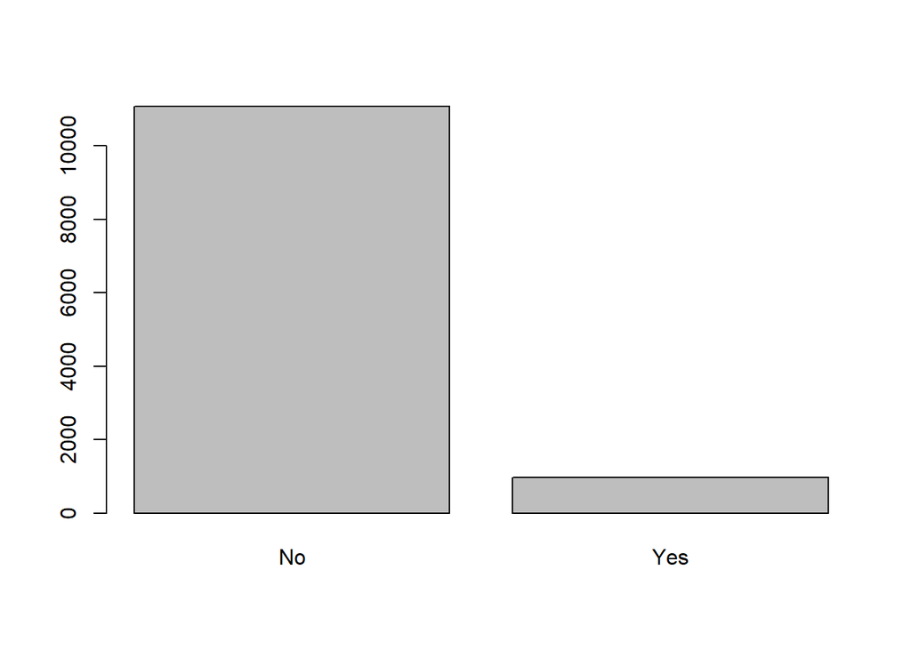

```r
#factorize
Fake_cccu_complete1$pregnant_between_waves<-factor(Fake_cccu_complete1$pregnant_between_waves, levels = c(0,1), labels = c("No", "Yes"))


plot(Fake_cccu_complete1$pregnant_between_waves)
```

##4.12 had_baby_between_waves Since September 2012, did you experience any of the following?: I had a baby

```r
#overview
table(Fake_cccu_complete1$PREG_r) #<-referring now to PREG_r which combines all PREG values t1-t4
```

```
##
## (1) I had a miscarriage   (2) I had an abortion        (3) I had a baby
##                     106                      34                     406
##                   (4) I (5) I might be pregnant   (6) None of the above
##                     422                     377                   10698
```

```r
table(is.na(Fake_cccu_complete1$PREG_r))
```

```
##
## FALSE  TRUE
## 12043    38
```

```r
#recoding in 0 = no baby and 1 = baby

Fake_cccu_complete1 <- Fake_cccu_complete1 %>%
  mutate(had_baby_between_waves = ifelse(PREG_r=="(3) I had a baby", 1, ifelse(PREG_r == "(-1) Refused", NA, 0)))

table(Fake_cccu_complete1$had_baby_between_waves)
```

```
##
##     0     1
## 11637   406
```

```r
table(is.na(Fake_cccu_complete1$had_baby_between_waves))
```

```
##
## FALSE  TRUE
## 12043    38
```

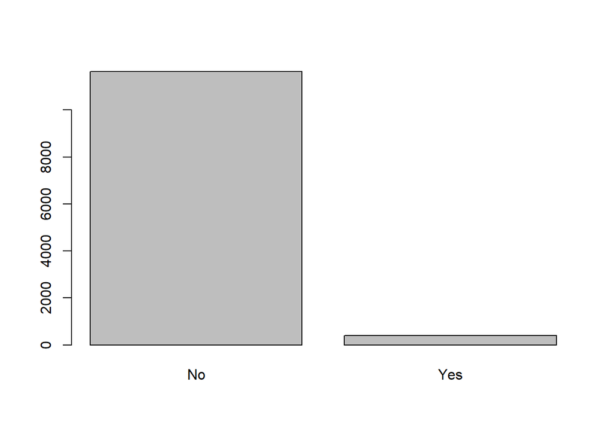

```r
#factorize

Fake_cccu_complete1$had_baby_between_waves<-factor(Fake_cccu_complete1$had_baby_between_waves, levels = c(0,1), labels = c("No", "Yes"))


plot(Fake_cccu_complete1$had_baby_between_waves)
```

##4.13 Relationship Duration Relationship information is stored seperately for (items refer to item about gender of partner): * Q3B_A: Married couples * Q3B_B: Non-married but living together couples * Q3B_C: Dating couples (one partner) * Q3B_D1: Dating couples (first of several partners) We exclude any further dating partners (Q3B_D2, Q3B_E1, Q3B_E2)

For dating partners, we have further information, whether the relationship is classified as a “special romantic relationship with each other” (Q4_C and Q4_D1). We only want to count dating relationship as serious relationships, if participants indicated that they are in a romantic relationship.

Therefore, we form a new variable “partnered”, that indicates whether a person is in a relationship (non-missing Q3_A or Q3_B, non-missing Q3B_C and Q4_C == 1, non-missing Q3B_D1 and Q4_D1 == 1), or single (everybody else).

```r
Fake_cccu_complete1 <- Fake_cccu_complete1 %>%
  mutate(
    partnered = case_when(
    !is.na(Q3B_A) ~ 1,
    !is.na(Q3B_B) ~ 1,
    !is.na(Q3B_C) & Q4_C == 1 ~ 1,
    !is.na(Q3B_D1) & Q4_D1 == 1 ~ 1,
    TRUE ~ 0
    )
  )

table(Fake_cccu_complete1$partnered)
```

```
##
##    0    1
## 5063 7018
```

This number (7018 timepoints with partnered values) is lower than in the original data because the missings in the simulated data are random (e.g. somebody can have no missings in Q3_A and Q3_B which will not be possible based on real data). Therefore, we cant check 100% if our code is correct here and have to compare results for the real data with the codebook.

For relationship duration we need to combine items MONTHSA, MONTHSB, MONTHSC and MONTHSD1 (with a descending hierarchy). Same needs to be done for YEARSA, YEARSB, YEARSC and YEARSD1. We will first combine them in two columnes (rel_dur_months and rel_dur_years).

```r
Fake_cccu_complete1 <- Fake_cccu_complete1 %>%
  mutate(
    rel_dur_months = case_when(
      !is.na(Q3B_A) ~ MONTHSA,
      !is.na(Q3B_B) ~ MONTHSB,
      !is.na(Q3B_C) & Q4_C == 1 ~ MONTHSC,
      !is.na(Q3B_D1) & Q4_D1 == 1 ~ MONTHSD1
    ),
    rel_dur_years = case_when(
      !is.na(Q3B_A) ~ YEARSA,
      !is.na(Q3B_B) ~ YEARSB,
      !is.na(Q3B_C) & Q4_C == 1 ~ YEARSC,
      !is.na(Q3B_D1) & Q4_D1 == 1 ~ YEARSD1
    ),
  )

table(is.na(Fake_cccu_complete1$rel_dur_months))
```

```
##
## FALSE  TRUE
##  7018  5063
```

```r
table(is.na(Fake_cccu_complete1$rel_dur_years))
```

```
##
## FALSE  TRUE
##  2687  9394
```

```r
table(Fake_cccu_complete1$rel_dur_months)
```

```
##
##    0    1    2    3    4    5    6    7    8    9   10   11
## 6260   73   83   84   61   72  103   46   50   45   68   73
```

```r
table(Fake_cccu_complete1$rel_dur_years)
```

```
##
##    0   12   24   36   48   60   72   84   96  108  120  132  144  156  168  180
## 1576   33   61   72   92   97   80  115   76   71   84   55   63   43   41   33
##  192  204  216  228  240  252  264  276  324  540  624
##   18   22   23    9    6    5    6    3    1    1    1
```

Again, these numbers (especially the zeros) dont represent correct numbers so should not be interepreted here.

Now we combine years and months to one variable rel_dur (in months).

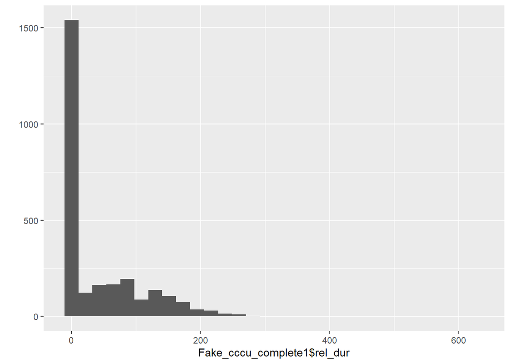

```r
Fake_cccu_complete1 <- Fake_cccu_complete1 %>%
  mutate(rel_dur = rel_dur_years + rel_dur_months)

library(ggplot2)
qplot(Fake_cccu_complete1$rel_dur)
```

```r
quantile(Fake_cccu_complete1$rel_dur, na.rm = T)
```

```
##   0%  25%  50%  75% 100%
##    0    0    5   84  627
```

```r
Fake_cccu_complete1 <- Fake_cccu_complete1 %>%
  mutate(
    rel_dur_factor = case_when(
      is.na(rel_dur) ~ "Single",
      rel_dur <= quantile(Fake_cccu_complete1$rel_dur, na.rm = T)[[2]] ~ "0q-25q",
      rel_dur <= quantile(Fake_cccu_complete1$rel_dur, na.rm = T)[[3]] ~ "26q-50q",
      rel_dur <= quantile(Fake_cccu_complete1$rel_dur, na.rm = T)[[4]] ~ "51q-75q",
      rel_dur > quantile(Fake_cccu_complete1$rel_dur, na.rm = T)[[4]] ~ "76q-100q",
    )
  )

Fake_cccu_complete1$rel_dur_factor <- factor(Fake_cccu_complete1$rel_dur_factor,
                                             levels = c("Single", "0q-25q", "26q-50q", "51q-75q",
                                                        "76q-100q"),
                                             labels = c("Single", "0q-25q", "26q-50q", "51q-75q",
                                                        "76q-100q"))

table(is.na(Fake_cccu_complete1$rel_dur_factor))
```

```
##
## FALSE
## 12081
```

```r
crosstabs(~rel_dur + rel_dur_factor, data = Fake_cccu_complete1)
```

```
##        rel_dur_factor
## rel_dur Single 0q-25q 26q-50q 51q-75q 76q-100q
##    0         0   1140       0       0        0
##    1         0      0      45       0        0
##    2         0      0      45       0        0
##    3         0      0      38       0        0
##    4         0      0      35       0        0
##    5         0      0      48       0        0
##    6         0      0       0      59        0
##    7         0      0       0      28        0
##    8         0      0       0      29        0
##    9         0      0       0      29        0
##    10        0      0       0      44        0
##    11        0      0       0      36        0
##    12        0      0       0      27        0
```

[output cut: 168 more lines]

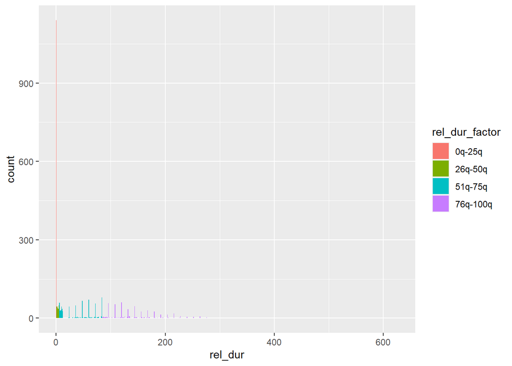

```r
ggplot(aes(rel_dur,  fill = rel_dur_factor), data = Fake_cccu_complete1) + geom_histogram(binwidth = 1)
```

##4.14 SEXUAL SATISFACTION: How satisfied is R in his / her sexual relationship?

```r
#overview
table(Fake_cccu_complete1$SEXSAT)
```

```
##
##    1    2    3    4    5    6    7
##  202  357  726 1720 2520 4593  204
```

```r
#recoding
Fake_cccu_complete1 <- Fake_cccu_complete1 %>%
  mutate(sexual_satisfaction = ifelse(SEXSAT == "1", 1,
                                      ifelse(SEXSAT == "2", 2,
                                                                                                   ifelse(SEXSAT == "3", 3,
                                                                                                          ifelse(SEXSAT == "4", 4,
                                                                                                                 ifelse(SEXSAT == "5", 5, ifelse(SEXSAT == "6",6, NA)))))))


Fake_cccu_complete1$sexual_satisfaction <- as.numeric(Fake_cccu_complete1$sexual_satisfaction)

table(Fake_cccu_complete1$sexual_satisfaction)
```

```
##
##    1    2    3    4    5    6
##  202  357  726 1720 2520 4593
```

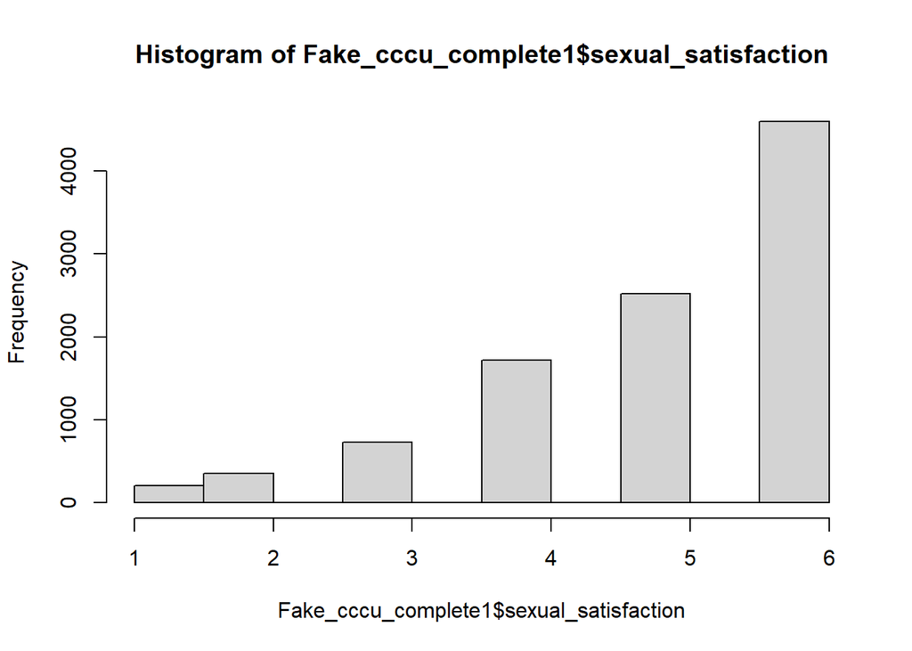

```r
hist(Fake_cccu_complete1$sexual_satisfaction)
```

## 4.15 SEX In LAST 30 days? SEXMO

```r
#overview
table(Fake_cccu_complete1$SEXMO)
```

```
##
##   (-1) Refused         (0) No        (1) Yes  (3) Dont Know (4) Didnt care
##             21           2704           9278              0              0
```

```r
#recoding
Fake_cccu_complete1<- Fake_cccu_complete1 %>%
  mutate(sex_inlast30days = recode(SEXMO,
                                    "(-1) Refused"="NA",
                                  "(0) No"="0",
                                 "(1) Yes" = "1",
                                 "(3) Dont Know" = "NA",
                                 "(4) Didnt care" = "NA"))
table(Fake_cccu_complete1$sex_inlast30days)
```

```
##
##   NA    0    1
##   21 2704 9278
```

```r
#factorize
Fake_cccu_complete1$sex_inlast30days<-factor(Fake_cccu_complete1$sex_inlast30days, levels = c(0,1), labels = c("No", "Yes"))

sum(is.na(Fake_cccu_complete1$sex_inlast30days))
```

```
## [1] 99
```

##4.16 Sexual Frequency: NSEXMO: how many times sex in last 30 days

```r
#overview:
table(Fake_cccu_complete1$NSEXMO)
```

```
##
##   (-1) Refused          (1) 1        (2) 2-5       (3) 6-10 (4) 11 or more
##              0            808           4163           2662           1663
```

```r
#overview
table(Fake_cccu_complete1$sex_inlast30days)
```

```
##
##   No  Yes
## 2704 9278
```

```r
#building sexual frequency: if sex_inlast30days = 0 ("No") we want 0, if NSEXMO = 1 we want 1, if NSEXMO 2 = 2, 3 =3, 4 = 4, otherwise NA

Fake_cccu_complete1 <- Fake_cccu_complete1 %>%
  mutate(sex_freq = ifelse(sex_inlast30days == "No", 0,
                                      ifelse(NSEXMO == "(1) 1", 1,
                                                                                                   ifelse(NSEXMO == "(2) 2-5", 2,
                                                                                                          ifelse(NSEXMO == "(3) 6-10", 3,
                                                                                                                 ifelse(NSEXMO == "(4) 11 or more", 4, NA))))))

table(Fake_cccu_complete1$sex_freq)
```

```
##
##    0    1    2    3    4
## 2704  631 3224 2002 1300
```

```r
crosstabs(~sex_inlast30days + NSEXMO , data = Fake_cccu_complete1)
```

```
##                 NSEXMO
## sex_inlast30days (-1) Refused (1) 1 (2) 2-5 (3) 6-10 (4) 11 or more
##              No             0   174     898      646            344
##              Yes            0   631    3224     2002           1300
```

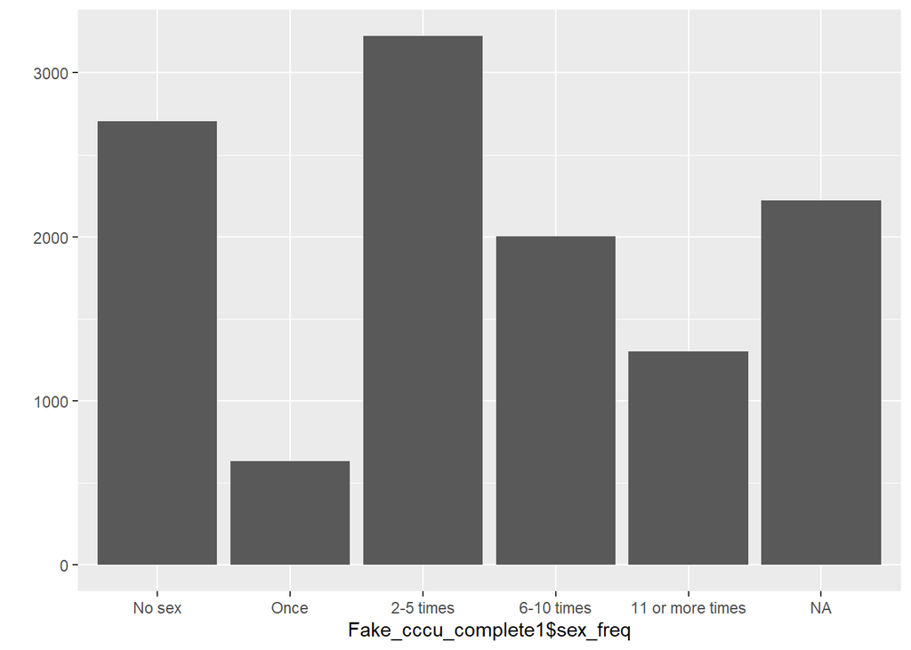

```r
#factorize
Fake_cccu_complete1$sex_freq<-factor(Fake_cccu_complete1$sex_freq, levels = c(0,1,2,3,4), labels = c("No sex", "Once", "2-5 times", "6-10 times", "11 or more times"))

qplot(Fake_cccu_complete1$sex_freq)
```

##4.19 hc use:grouping

```r
Fake_cccu_complete1 <- Fake_cccu_complete1 %>%
  mutate(hc = ifelse(PILL %contains% "1"|
                       PATCH %contains% "1" |
                       RING %contains% "1" |
                       DEPO %contains% "1" |
                       IMPLANT %contains% "1", 1,
                      ifelse(IUD %contains% "1", 2,
                             ifelse(CONDOMR %contains% "1"| #actively include non_hc user as 0
                                     VASECTOMY %contains% "1"|
                                     WITHDRAWR %contains% "1" |
                                     NFPR %contains% "1" |
                                     SPERMR %contains% "1" |
                                     NOBARRIER %contains% "1", 0, NA))),
         hc = ifelse(PILL %contains% "0" &
                       PATCH %contains% "0" &
                       RING %contains% "0" &
                       DEPO %contains% "0" &
                       IMPLANT %contains% "0" &
                        IUD %contains% "0", 0, hc))


table(Fake_cccu_complete1$hc)
```

```
##
##    0    1    2
## 6953 4324  804
```

```r
table(is.na(Fake_cccu_complete1$hc))
```

```
##
## FALSE
## 12081
```

```r
crosstabs(~IUD + hc, data = Fake_cccu_complete1)
```

```
##          hc
## IUD          0    1    2
##   (0) No  6953 3925    0
##   (1) Yes    0  399  804
```

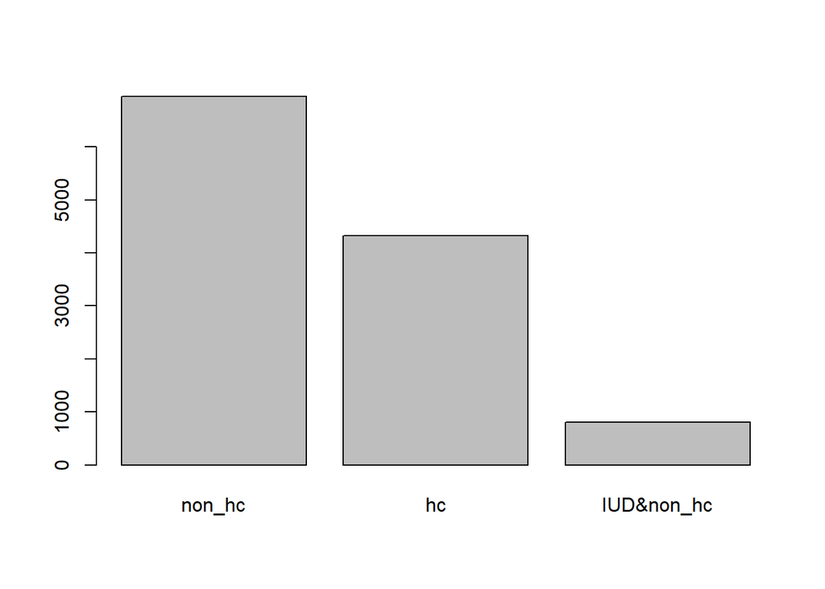

```r
#factorizing
Fake_cccu_complete1$hc<-factor(Fake_cccu_complete1$hc, levels = c(0,1,2), labels = c("non_hc", "hc", "IUD&non_hc"))


plot(Fake_cccu_complete1$hc)
```

##4.19.1 Building IUD next

```r
Fake_cccu_complete1 <- Fake_cccu_complete1 %>%
  group_by(CASEID) %>%
  mutate(IUD_next = lead(IUD)) %>%
  ungroup()

Fake_cccu_complete1 %>% select(CASEID, WAVE, IUD, IUD_next) %>% View()
```

##4.20 Contraceptive Satisfaction

```r
table(Fake_cccu_complete1$hc)
```

```
##
##     non_hc         hc IUD&non_hc
##       6953       4324        804
```

```r
#recoding values for hc satisfaction (note: 1 = very satisfied, for hypotheses 1 must be very dissatisfied)

##pill
table(Fake_cccu_complete1$Q23D_PILL)
```

```
##
##              (-1) Refused        (1) Very satisfied    (2) Somewhat satisfied
##                        22                      2314                      1110
## (3) Somewhat dissatisfied     (4) Very dissatisfied
##                       188                        47
```

```r
Fake_cccu_complete1 <- Fake_cccu_complete1 %>%
  mutate(Q23D_PILL_r = ifelse(Q23D_PILL %contains% "(1)", 4,
                              ifelse(Q23D_PILL %contains% "(2)", 3,
                                      ifelse(Q23D_PILL %contains% "(3)", 2,
                                             ifelse(Q23D_PILL %contains% "(4)", 1, NA)))))

table(Fake_cccu_complete1$Q23D_PILL_r)
```

```
##
##    1    2    3    4
##   47  188 1110 2314
```

```r
##Patch

table(Fake_cccu_complete1$Q23D_PATCH)
```

```
##
##              (-1) Refused        (1) Very satisfied    (2) Somewhat satisfied
##                         1                        33                         8
## (3) Somewhat dissatisfied     (4) Very dissatisfied
##                         6                         4
```

```r
Fake_cccu_complete1 <- Fake_cccu_complete1 %>%
  mutate(Q23D_PATCH_r = ifelse(Q23D_PATCH %contains% "(1)", 4,
                              ifelse(Q23D_PATCH %contains% "(2)", 3,
                                      ifelse(Q23D_PATCH %contains% "(3)", 2,
                                             ifelse(Q23D_PATCH %contains% "(4)", 1, NA)))))

table(Fake_cccu_complete1$Q23D_PATCH_r)
```

```
##
##  1  2  3  4
##  4  6  8 33
```

```r
##Depo
table(Fake_cccu_complete1$Q23D_DEPO)
```

```
##
##              (-1) Refused        (1) Very satisfied    (2) Somewhat satisfied
##                         5                       283                       106
## (3) Somewhat dissatisfied     (4) Very dissatisfied
##                        12                        19
```

```r
Fake_cccu_complete1 <- Fake_cccu_complete1 %>%
  mutate(Q23D_DEPO_r = ifelse(Q23D_DEPO %contains% "(1)", 4,
                              ifelse(Q23D_DEPO %contains% "(2)", 3,
                                      ifelse(Q23D_DEPO %contains% "(3)", 2,
                                             ifelse(Q23D_DEPO %contains% "(4)", 1, NA)))))

table(Fake_cccu_complete1$Q23D_DEPO_r)
```

```
##
##   1   2   3   4
##  19  12 106 283
```

```r
##Implant
table(Fake_cccu_complete1$Q23D_IMPLANT)
```

```
##
##              (-1) Refused        (1) Very satisfied    (2) Somewhat satisfied
##                         3                       144                        42
## (3) Somewhat dissatisfied     (4) Very dissatisfied
##                        16                         6
```

```r
Fake_cccu_complete1 <- Fake_cccu_complete1 %>%
  mutate(Q23D_IMPLANT_r = ifelse(Q23D_IMPLANT %contains% "(1)", 4,
                              ifelse(Q23D_IMPLANT %contains% "(2)", 3,
                                      ifelse(Q23D_IMPLANT %contains% "(3)", 2,
                                             ifelse(Q23D_IMPLANT %contains% "(4)", 1, NA)))))

table(Fake_cccu_complete1$Q23D_IMPLANT_r)
```

```
##
##   1   2   3   4
##   6  16  42 144
```

```r
##Ring
table(Fake_cccu_complete1$Q23D_RING)
```

```
##
##              (-1) Refused        (1) Very satisfied    (2) Somewhat satisfied
##                         4                       252                        57
## (3) Somewhat dissatisfied     (4) Very dissatisfied
##                         8                        12
```

```r
Fake_cccu_complete1 <- Fake_cccu_complete1 %>%
  mutate(Q23D_RING_r = ifelse(Q23D_RING %contains% "(1)", 4,
                              ifelse(Q23D_RING %contains% "(2)", 3,
                                      ifelse(Q23D_RING %contains% "(3)", 2,
                                             ifelse(Q23D_RING %contains% "(4)", 1, NA)))))

table(Fake_cccu_complete1$Q23D_RING_r)
```

```
##
##   1   2   3   4
##  12   8  57 252
```

```r
#recoding non-hc satisfaction values

#withdrawl

table(Fake_cccu_complete1$RSAT1)
```

```
##
## (000) didnâ\200\231t use/not applicable              (001) very satisfied
##                              3370                               974
##          (002) somewhat satisfied       (003) somewhat dissatisfied
##                              1119                               432
##              (004) very satisfied                  (005) don't know
##                               154                                 0
##                  (100) don't know
##                                 0
```

```r
Fake_cccu_complete1 <- Fake_cccu_complete1 %>%
  mutate(RSAT1_r = ifelse(RSAT1 %contains% "(001)", 4,
                              ifelse(RSAT1 %contains% "(002)", 3,
                                      ifelse(RSAT1 %contains% "(003)", 2,
                                             ifelse(RSAT1 %contains% "(004)", 1, NA)))))

table(Fake_cccu_complete1$RSAT1_r)
```

```
##
##    1    2    3    4
##  154  432 1119  974
```

```r
##vasectomy
table(Fake_cccu_complete1$RSAT2)
```

```
##
## (000) didnâ\200\231t use/not applicable              (001) very satisfied
##                              7369                                59
##          (002) somewhat satisfied       (003) somewhat dissatisfied
##                                13                                 4
##              (004) very satisfied                  (005) don't know
##                                 3                                 0
##                  (100) don't know
##                                 0
```

```r
Fake_cccu_complete1 <- Fake_cccu_complete1 %>%
  mutate(RSAT2_r = ifelse(RSAT2 %contains% "(001)", 4,
                              ifelse(RSAT2 %contains% "(002)", 3,
                                      ifelse(RSAT2 %contains% "(003)", 2,
                                             ifelse(RSAT2 %contains% "(004)", 1, NA)))))

table(Fake_cccu_complete1$RSAT2_r)
```

```
##
##  1  2  3  4
##  3  4 13 59
```

```r
##condoms
table(Fake_cccu_complete1$RSAT3)
```

```
##
## (000) didnâ\200\231t use/not applicable              (001) very satisfied
##                              1912                              1013
##          (002) somewhat satisfied       (003) somewhat dissatisfied
##                              1273                               339
##              (004) very satisfied                  (005) don't know
##                               130                                 0
##                  (100) don't know
##                                 0
```

```r
Fake_cccu_complete1 <- Fake_cccu_complete1 %>%
  mutate(RSAT3_r = ifelse(RSAT3 %contains% "(001)", 4,
                              ifelse(RSAT3 %contains% "(002)", 3,
                                      ifelse(RSAT3 %contains% "(003)", 2,
                                             ifelse(RSAT3 %contains% "(004)", 1, NA)))))

table(Fake_cccu_complete1$RSAT3_r)
```

```
##
##    1    2    3    4
##  130  339 1273 1013
```

```r
##natural /calender

table(Fake_cccu_complete1$RSAT4)
```

```
##
## (000) didnâ\200\231t use/not applicable              (001) very satisfied
##                              2303                               210
##          (002) somewhat satisfied       (003) somewhat dissatisfied
##                               194                                50
##              (004) very satisfied                  (005) don't know
##                                11                                 0
##                  (100) don't know
##                                 0
```

```r
Fake_cccu_complete1 <- Fake_cccu_complete1 %>%
  mutate(RSAT4_r = ifelse(RSAT4 %contains% "(001)", 4,
                              ifelse(RSAT4 %contains% "(002)", 3,
                                      ifelse(RSAT4 %contains% "(003)", 2,
                                             ifelse(RSAT4 %contains% "(004)", 1, NA)))))

table(Fake_cccu_complete1$RSAT4_r)
```

```
##
##   1   2   3   4
##  11  50 194 210
```

```r
##spermicid

table(Fake_cccu_complete1$RSAT5)
```

```
##
## (000) didnâ\200\231t use/not applicable              (001) very satisfied
##                              2381                                51
##          (002) somewhat satisfied       (003) somewhat dissatisfied
##                                69                                13
##              (004) very satisfied                  (005) don't know
##                                 9                                 0
##                  (100) don't know                          (-01) -1
##                                 0                                 2
```

```r
Fake_cccu_complete1 <- Fake_cccu_complete1 %>%
  mutate(RSAT5_r = ifelse(RSAT5 %contains% "(001)", 4,
                              ifelse(RSAT5 %contains% "(002)", 3,
                                      ifelse(RSAT5 %contains% "(003)", 2,
                                             ifelse(RSAT5 %contains% "(004)", 1, NA)))))

table(Fake_cccu_complete1$RSAT5_r)
```

```
##
##  1  2  3  4
##  9 13 69 51
```

```r
#building contra_satisfaction

Fake_cccu_complete1 <- Fake_cccu_complete1 %>%
  mutate(contra_satis = ifelse(hc == "hc",
                                      pmax(Q23D_PILL_r, Q23D_PATCH_r, Q23D_DEPO_r,
                                           Q23D_IMPLANT_r, Q23D_RING_r,
                                           na.rm = TRUE),
                                      pmax(RSAT1_r, RSAT2_r, RSAT3_r, RSAT4_r, RSAT5_r,
                                           na.rm = TRUE)))

table(Fake_cccu_complete1$contra_satis)
```

```
##
##    1    2    3    4
##  169  432 1836 2459
```

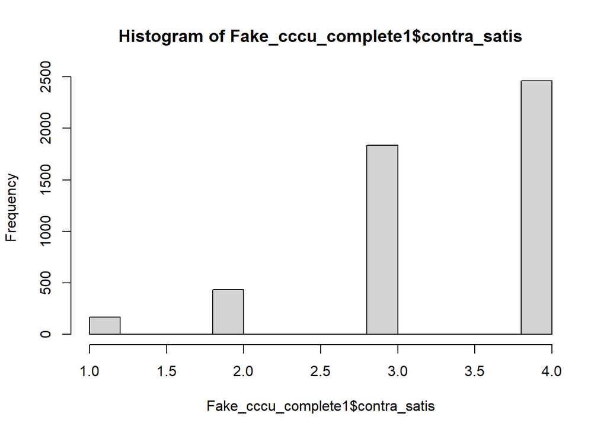

```r
x = Fake_cccu_complete1 %>%
  select(hc, Q23D_PILL_r, Q23D_PATCH_r, Q23D_DEPO_r,
         Q23D_IMPLANT_r, Q23D_RING_r,RSAT1_r, RSAT2_r, RSAT3_r, RSAT4_r, RSAT5_r, contra_satis)

hist(Fake_cccu_complete1$contra_satis)
```

##4.21 Contraceptive Duration -> only duration values for hc users are needed for subanalysis -> we have t1: years & month duration t2-4: last 6 month –> we need to pmax() -> get higher duration value for when women are using a combination –> then combine values from years and month –> then add t1 + t2 usw…

```r
#combine values first bc we only want maximum for combined time
# not e.g. max years for pill and max months for patch
Fake_cccu_complete1 <- Fake_cccu_complete1 %>%
  mutate(hc_dur_pill = YPILL + MPILL,
         hc_dur_patch = YPATCH + MPATCH,
         hc_dur_ring = YRING + MRING,
         hc_dur_depo = YDEPO + MDEPO,
         hc_dur_implant = YIMPLANT + MIMPLANT)
# for the simulated data this is a problem, bc if Y or M are missing, hc_dur is missing as well
# this is not a problem for real data, bc !is.na(Y) <--> !is.na(M)

# find longest time
Fake_cccu_complete1 <- Fake_cccu_complete1 %>%
  mutate(hc_dur = pmax(hc_dur_pill, hc_dur_patch, hc_dur_ring, hc_dur_depo, hc_dur_implant,
                            na.rm = TRUE))

# distribution at t1
table(Fake_cccu_complete1$hc_dur)
```

```
##
##  0  1  2  3  4  5  6  7  8  9 10 11 12 13 14 15 16 17 18 19 20 21 22 23 24 26
## 43 29 42 35 33 31 39 30 29 25 15 16 15 13 13 18  8  6  2  3  1  2  2  1  2  1
```

```r
# missings:
table(is.na(Fake_cccu_complete1$hc_dur)) # a lot of missing bc of simulated data
```

```
##
## FALSE  TRUE
##   454 11627
```

```r
# check this for real data (shouldnt be that much missing!)

# recode duration time for t2 - t4 into numeric values
Fake_cccu_complete1 = Fake_cccu_complete1 %>%
  mutate(Q23A_PILL = ifelse(Q23A_PILL %contains% "(1)", 0,
                              ifelse(Q23A_PILL %contains% "(2)", 1,
                                      ifelse(Q23A_PILL %contains% "(3)", 2,
                      ifelse(Q23A_PILL %contains% "(4)", 3,
                             ifelse(Q23A_PILL %contains% "(5)", 4,
                                    ifelse(Q23A_PILL %contains% "(6)", 5,
                                           ifelse(Q23A_PILL %contains% "(7)", 6,                                       ifelse(Q23A_PILL %contains% "(-1)", NA, NA)))))))),
         Q23A_PATCH = ifelse(Q23A_PATCH %contains% "(1)", 0,
                   ifelse(Q23A_PATCH %contains% "(2)", 1,
                          ifelse(Q23A_PATCH %contains% "(3)", 2,
                                 ifelse(Q23A_PATCH %contains% "(4)", 3,
                                        ifelse(Q23A_PATCH %contains% "(5)", 4,
                                               ifelse(Q23A_PATCH %contains% "(6)", 5,
                                                      ifelse(Q23A_PATCH %contains% "(7)", 6,                                       ifelse(Q23A_PATCH %contains% "(-1)", NA, NA)))))))),
         Q23A_RING = ifelse(Q23A_RING %contains% "(1)", 0,
                   ifelse(Q23A_RING %contains% "(2)", 1,
                          ifelse(Q23A_RING %contains% "(3)", 2,
                                 ifelse(Q23A_RING %contains% "(4)", 3,
                                        ifelse(Q23A_RING %contains% "(5)", 4,
                                               ifelse(Q23A_RING %contains% "(6)", 5,
                                                      ifelse(Q23A_RING %contains% "(7)", 6,                                       ifelse(Q23A_RING %contains% "(-1)", NA, NA)))))))),
         Q23A_DEPO = ifelse(Q23A_DEPO %contains% "(1)", 0,
                   ifelse(Q23A_DEPO %contains% "(2)", 1,
                          ifelse(Q23A_DEPO %contains% "(3)", 2,
                                 ifelse(Q23A_DEPO %contains% "(4)", 3,
                                        ifelse(Q23A_DEPO %contains% "(5)", 4,
                                               ifelse(Q23A_DEPO %contains% "(6)", 5,
                                                      ifelse(Q23A_DEPO %contains% "(7)", 6,                                       ifelse(Q23A_DEPO %contains% "(-1)", NA, NA)))))))),
         Q23A_IMPLANT = ifelse(Q23A_IMPLANT %contains% "(1)", 0,
                   ifelse(Q23A_IMPLANT %contains% "(2)", 1,
                          ifelse(Q23A_IMPLANT %contains% "(3)", 2,
                                 ifelse(Q23A_IMPLANT %contains% "(4)", 3,
                                        ifelse(Q23A_IMPLANT %contains% "(5)", 4,
                                               ifelse(Q23A_IMPLANT %contains% "(6)", 5,
                                                      ifelse(Q23A_IMPLANT %contains% "(7)", 6,                                       ifelse(Q23A_IMPLANT %contains% "(-1)", NA, NA)))))))))


# find values based on t2-t4
Fake_cccu_complete1 <- Fake_cccu_complete1 %>%
  mutate(hc_dur_add = pmax(Q23A_PILL, Q23A_PATCH, Q23A_RING, Q23A_DEPO, Q23A_IMPLANT,
                            na.rm = TRUE))

# distribution
table(Fake_cccu_complete1$hc_dur_add)
```

```
##
##    0    1    2    3    4    5    6
##   24   75  133   85   75   82 2170
```

```r
# missingness
table(is.na(Fake_cccu_complete1$hc_dur_add)) # a lot of missing bc of simulated data
```

```
##
## FALSE  TRUE
##  2644  9437
```

```r
# now calculate total duration values t1 + t2-4
Fake_cccu_complete1 = Fake_cccu_complete1 %>%
  group_by(CASEID) %>%
  mutate(hc_prev = lag(hc),
         hc_dur_prev = lag(hc_dur)) %>%
  ungroup() %>%
  mutate(hc_dur_1 = hc_dur,
         hc_dur_2 = ifelse(WAVE == "t2" & hc == hc_prev,
                           hc_dur_prev + 6,
                           ifelse(WAVE == "t2" & hc == "hc" & hc_prev == "non_hc",
                                  hc_dur_add,
                                  NA))) %>%
  group_by(CASEID) %>%
  mutate(hc_dur_prev = lag(hc_dur_2)) %>%
  ungroup() %>%
  mutate(hc_dur_3 = ifelse(WAVE == "t3" & hc == hc_prev,
                           hc_dur_prev + 6,
                           ifelse(WAVE == "t3" & hc == "hc" & hc_prev == "non_hc",
                                  hc_dur_add,
                                  NA))) %>%
  group_by(CASEID) %>%
  mutate(hc_dur_prev = lag(hc_dur_3)) %>%
  ungroup() %>%
  mutate(hc_dur_4 = ifelse(WAVE == "t4" & hc == hc_prev,
                           hc_dur_prev + 6,
                           ifelse(WAVE == "t4" & hc == "hc" & hc_prev == "non_hc",
                                  hc_dur_add,
                                  NA))) %>%
  select(-hc_prev, -hc_dur_prev)

table(Fake_cccu_complete1$hc_dur_1)
```

```
##
##  0  1  2  3  4  5  6  7  8  9 10 11 12 13 14 15 16 17 18 19 20 21 22 23 24 26
## 43 29 42 35 33 31 39 30 29 25 15 16 15 13 13 18  8  6  2  3  1  2  2  1  2  1
```

```r
table(Fake_cccu_complete1$hc_dur_2)
```

```
##
##   0   1   2   3   4   5   6   7   8   9  10  11  12  13  14  15  16  17  18  19
##   2   7  12   8  16   3 207  11  12  12   8  10  13   9   9   5   2   7   7   4
##  20  21  22  23  24  25  27  28  30
##   6   5   3   2   1   2   1   1   1
```

```r
table(Fake_cccu_complete1$hc_dur_3)
```

```
##
##   0   1   2   3   4   5   6   7   8   9  10  12  13  14  15  16  17  18  19  20
##   3   2   8   9   5   5 136   2   2   2   3  48   4   7   1   2   3   5   6   3
##  21  23  24  25  26  27  28  29  31  33  36
##   5   2   2   1   5   1   2   1   1   1   1
```

```r
table(Fake_cccu_complete1$hc_dur_4)
```

```
##
##   0   1   2   3   5   6   7   8   9  12  14  15  16  18  20  23  24  25  26  27
##   2   5   5   8   8 104   2   1   2  39   1   1   1  10   2   1   2   4   2   3
##  29  30  32  35  37  39
##   1   2   3   1   1   1
```

```r
#combine waves
Fake_cccu_complete1 = Fake_cccu_complete1 %>%
  mutate(hc_dur = ifelse(!is.na(hc_dur_1), hc_dur_1,
                         ifelse(!is.na(hc_dur_2), hc_dur_2,
                                ifelse(!is.na(hc_dur_3), hc_dur_3,
                                       ifelse(!is.na(hc_dur_4), hc_dur_4, NA)))))

table(Fake_cccu_complete1$hc_dur)
```

```
##
##   0   1   2   3   4   5   6   7   8   9  10  11  12  13  14  15  16  17  18  19
##  50  43  67  60  54  47 486  45  44  41  26  26 115  26  30  25  13  16  24  13
##  20  21  22  23  24  25  26  27  28  29  30  31  32  33  35  36  37  39
##  12  12   5   6   7   7   8   5   3   2   3   1   3   1   1   1   1   1
```

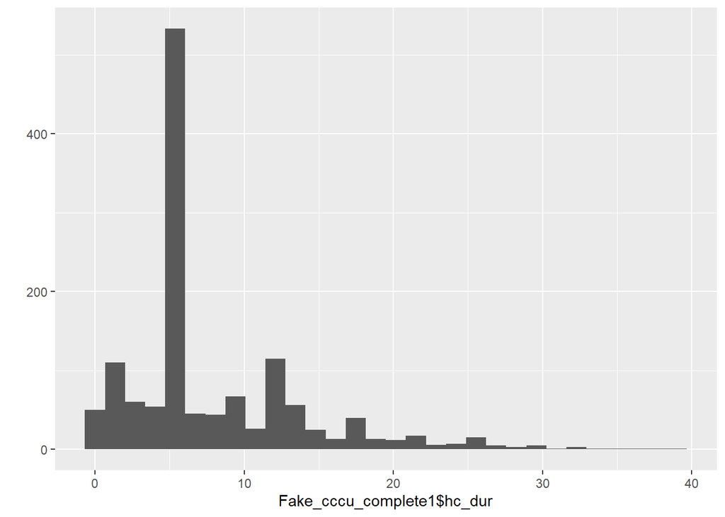

```r
qplot(Fake_cccu_complete1$hc_dur)
```

##4.22 switch

```r
Fake_cccu_complete1 <- Fake_cccu_complete1 %>%
  group_by(CASEID) %>%
  mutate(hc_next = lead(hc),
         switch = case_when(hc == hc_next ~ 0,
                            hc != hc_next ~ 1)) %>%
  ungroup()

Fake_cccu_complete1 %>% select(CASEID, WAVE, hc, hc_next, switch) %>% View()

Fake_cccu_complete1 %>%
  filter(WAVE != "t4") %>%
  select(switch) %>%
  is.na() %>%
  table()
```

```
## .
## FALSE  TRUE
##  7447  2792
```

```r
table(is.na(Fake_cccu_complete1$switch))
```

```
##
## FALSE  TRUE
##  7447  4634
```

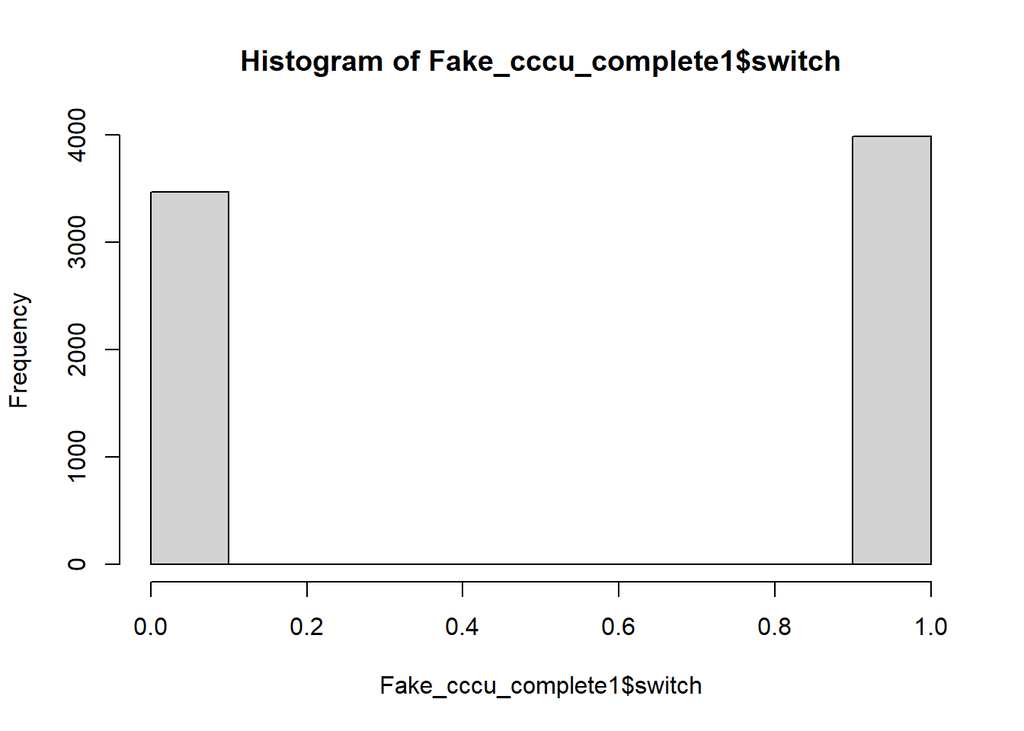

```r
hist(Fake_cccu_complete1$switch)
```

#5. Saving Data

```r
save(Fake_cccu_complete1,file = "Fake_cccu_complete1.RData")

load("Fake_cccu_complete1.RData")
```